# Time and memory: Moore-Penrose inversion of random matrices

Let $2^n$ be the number of elements in an ultrasound array. Then there are on the order of $2^{2n}$ pixels and $2^{2n}$ paths from transmitters to receivers. Each path will intersect on the order of $2^n$ pixels, hence there are on the order of $2^{3n}$ intersections. The length of each must be available or recomputed on demand.

The figure illustrates the case for $n=4.$

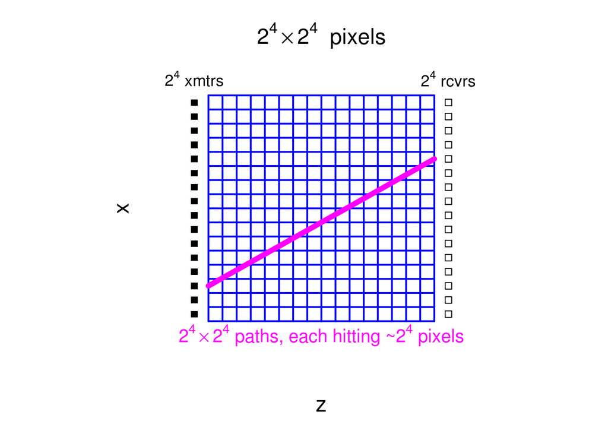

In the equation,$ToF = S \times b,$$b$ which represents pixels, and $ToF$ which represents measured times of flight, are vectors of length $2^{2n}$. The matrix, $S$, which represents lengths of path and pixel intersections is theoretically $2^{2n} \times 2^{2n}$, hence would have $2^{4n}$ elements but only about $2^{3n}$ nonzero elements.

For $n \le 7$, $2^{3n}$ is not prohibitive for commodity hardware and software; $2^{4n}$ may be.

Of course, no attempt was made to optimize. Test matrices were random, not sparse, and R’s default Moore-Penrose inversion function, `gint` in package `MASS`, was used. R’s `Matrix` package has specialized functions, including Moore-Penrose, for sparse matrices.